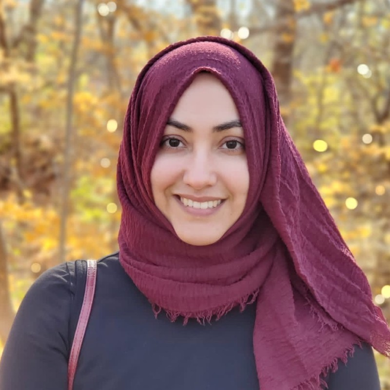

### **Informational Interview With Sumaiyya Thawer**

Author : Yasini Muhamedi Kokoda  
Date : 07/05/2025

#### **Introduction**

In this informational interview, I had a wonderful time speaking with Sumaiyya Thawer. Sumaiyya is an epidemiologist at Swiss Tropical and Public Health Institute (Swiss TPH). She has over eight years of experience in surveillance, monitoring and evaluation with a passion for promoting data use for evidence-based decision making to support the equitable distribution of disease control interventions. She provides technical support to Tanzania National Malaria Control Program (NMCP) as well as other select African countries in the capacity of sub-national tailoring of interventions through her comprehensive quantitative skills such as retrospective impact evaluation, time series analysis, geo-spatial modelling for disease risk mapping, statistical modelling, health facility routine data management and data visualization.

#### **Discussion**

###### **Can you share with me the skills and experience crucial for your role?**

She explained that to succeed as an epidemiologist, it is essential to have strong statistical skills, experience in geospatial statistics, GIS for mapping, a solid understanding of disease patterns and its determinants, and proficiency in using R or Stata softwares for statistical analysis. She emphasized that she developed and strengthened most of these skills during her PhD in epidemiology.

###### **What are the most challenging and rewarding aspects of your role?**

Sumaiyya noted that one of the most challenging aspects of her work is translating research findings into operational tools or strategies. She emphasized that research outputs are not always immediately applicable in practice, and it often requires thoughtful adaptation to make them accessible and useful to broader, non-technical audiences. On the rewarding side, she highlighted the extensive dissemination efforts she and her colleagues under the TEMT project have undertaken across various levels of the health system in Tanzania. For example, they have conducted multiple workshops focused on capacitating the use of malaria dashboards and stratification maps for decision making at regional and council levels. Notably, the malaria stratification maps were successfully integrated into the National Malaria Strategic Plans (NMSPs), marking a significant achievement in bridging research and policy.

###### **Can you share with me the top two of your most impact full publications?**

Sumaiyya shared her work that she led on the development of a novel and pragmatic data driven approach for sub-national (macro) and sub-council (micro) stratification of malaria risk to support NMCP in implementing a tailored malaria control approach and move towards decentralization of malaria control planning.

- [Sub-national stratification of malaria risk in mainland Tanzania](https://pubmed.ncbi.nlm.nih.gov/32384923/)
- [The use of routine health facility data for micro-stratification of malaria risk in mainland Tanzania](https://pubmed.ncbi.nlm.nih.gov/36401310/)

###### **What advice would you give to someone looking to publish their first paper?**

Sumaiyya emphasized the importance of developing strong scientific writing skills, especially for those new to publishing. She noted that before beginning to write, it is essential to create a clear roadmap that outlines the goal, objectives, and key messages intended for the audience. After completing the analysis, one should focus on identifying results that effectively support these messages and consider the context in which the target audience will best understand and engage with the findings.

###### **How do you see the field of epidemiology evolving in the next few years?**

Sumaiyya reflected on the historical evolution of malaria epidemiology, noting that in earlier periods, decisions were often based on expert judgment due to the widespread prevalence of malaria across regions. However, as malaria transmission began to decline and risk patterns became more heterogeneous and complex, the reliance on data-driven decision-making increased. She anticipates that the field of malaria epidemiology will continue to grow in complexity in the coming years. Nonetheless, advancements in big data analytics, artificial intelligence, and modern data science tools are expected to enable the development of more sophisticated solutions. Importantly, she foresees an increasing emphasis on the use of localized data to inform decision-making within countries.

###### **Do you have any recommendation for someone new in the field to read or community to join?**

For malaria epidemiology, she advised to visit the WHO malaria guidelines as well as specific country’s guidelines to see how they align each other. This will help to grasp the context. As for community to join, she mentioned [AMMnet.](https://ammnet.org/) It is a global network of mathematical modelers, data scientist, and Analysts for malaria.

#### **Conclusion**

The conversation with Sumaiyya Thawer offered valuable insights into the evolving field of malaria epidemiology and the essential skills required to succeed in it. Her experience underscores the importance of strong analytical capabilities, scientific communication, and the ability to bridge research with policy and practice.